# Homework 3: Is Donald Trump going to win the republican nomination?

## Problem 1F

In our `results` table, we have one row for each candidate in each poll. Transform the `results` table to have one row for each poll and columns for each Rubio and Trump. Next, create a column called `diff` with the difference between Trump and Rubio. Hint: Remove the `first_name` and `last_name` columns then use the `tidyr` function `spread()`.

```r
##Your code here

# First remove first_name and last_name since they're different for the same poll, it'll result in multiple rows for a single poll
library(tidyr)

# remove duplicated rows first, then spread
results <-distinct(results) %>% select(-first_name, -last_name) %>% spread( key=choice, value=value) %>% mutate(diff=Trump-Rubio)
```

## Problem 1G

For each poll in the `results` table, we want to know the start date and the end date of the poll along with the pollster name and the type of poll it was. Hint: This information is in the `polls` component of `race2016`. You can select the relevant columns then use the `id` column to join the tables. One of the `join` functions in `tidyr` will do the trick.

```r
##Your code here

# View 'polls'
# View(polls)
# relevant information in 'polls': start_date, end_date, pollster(pollster name), method(type of poll)

# Left join by id
library(tidyr)
results <- results %>% left_join(select(polls,id,pollster,start_date, end_date, method), by="id")
```

## Problem 1H

Study the type of values in the `pollster` column. Notice that you have many different values but that certain names commonly appear in these values. For example, consider the name “NBC” in the `pollster` column. NBC here is the Survey House. Use a join function again to add the survey house to the `results` table. Rename the column `house`. Hint: `race2016$survey_house` has the information you need.

```r
##Your code here

# View 'survey_houses'
# View(survey_houses) # change 'name' into 'house'

# rename(data, newvar=oldvar)
results <- results%>% left_join(survey_houses, by="id") %>% rename( house=name)
```

## Problem 2

We now have a table with all the information we need. We will now use the results from Iowa, New Hampshire, Nevada and South Carolina to determine how to create a prediction for upcoming primaries.

## Problem 2A

Use an internet search to determine the results for the Iowa, New Hampshire, Nevada and South Carolina primaries for the top two candidates. Create a table called `actual` with this information. Also, create a column with the actual election difference. Use a join function to add this information to our `results` table.

```r
##Your code here
library(readr)
setwd("C:/Users/xiz933/Desktop/Files/Data Science/2016/xz2315-2016HW3")
actual <- read_csv("Presidential Primary.csv")

# Merge with 'results' tbl
dataQ2a <-  left_join(results, mutate(actual, actual_diff=as.numeric(actual_Trump)-as.numeric(actual_Rubio)), by='state')
```

## Problem 2B

Create boxplots of the poll results for Trump in Iowa stratified by the pollster survey house for polls having more than 4 total results. Add a horizontal line with the actual results. Hint: Use the `group_by`, `mutate`, `filter` and `ungroup` functions in `dplyr` for the filtering step.

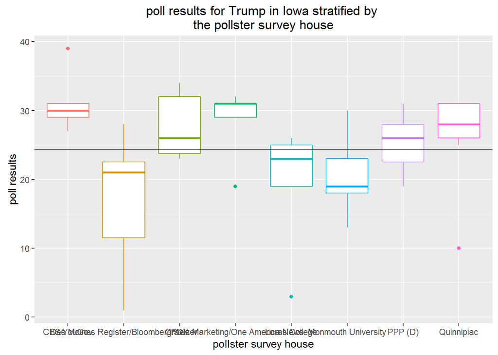

```r
##Your code here
library(ggplot2)

dataQ2b <- dataQ2a %>% filter(state=='IA'& !is.na(Trump)) %>% group_by(pollster) %>% filter(n()>4) %>% ungroup
dataQ2b  %>% ggplot(aes(x=pollster,y=Trump,colour=factor(pollster))) + geom_boxplot( ) + geom_hline(aes(yintercept=actual_Trump )) +labs(title="poll results for Trump in Iowa stratified by
the pollster survey house", x="pollster survey house", y='poll results')+theme(legend.position = "none")
```

## Problem 2C

Using the poll results for Trump in Iowa, compute the standard deviation for the results from each pollster house for polls having more than 4 total results. Then, study the typical standard deviation sizes used in these polls. Create a new table with two columns: the observed standard deviation and the standard deviations that theory predicts. For the prediction you have several observations. Pick the smallest one. Which is larger, the observed or the theoretical?

Your Answer here.

We assume that for each pollster house, the underlying true probability of voting for Trump is $p$ for all polls taken place, and individual voters independently votes. Thus, the random variable ‘Voting for Trump’ follows a Bernoulli distribution with probability of $p$. Now, we have several observations (several polls), each observation follows a Binomial distribiution (N,p). The $p$ has a sampling distribution and we can compute the standatd deviation for this sampling distribution; alternatively, central limit theorem tells us that $hat{p}$ follows a normal distribution with expected value $p$ and standard error approximately equal to $sqrt{\hat{p} (1-\hat{p})} / \sqrt{N}$, so we can compute theoretical standard deviation using each poll or obervation. Now, for each pollster survey house, we have an observed SD, and several theoretical SD (choose the smallest one), compare how they differ.

```r
##Your code here
dataQ2c <- dataQ2a %>% filter(state=='IA'& !is.na(Trump)) %>% group_by(pollster) %>% filter(n()>4) %>% ungroup

# observed standard deviation for each pollster survey house
obs <- dataQ2c %>% group_by(pollster) %>% summarise(obs_SD=sd(Trump/100))
obs
```

```
## Source: local data frame [8 x 2]
##
##                               pollster     obs_SD
##                                  (chr)      (dbl)
## 1                           CBS/YouGov 0.04604346
## 2 Des Moines Register/Bloomberg/Selzer 0.10221360
## 3                                  FOX 0.05085928
## 4   Gravis Marketing/One America News  0.05366563
## 5                        Loras College 0.09444575
## 6                  Monmouth University 0.06348228
## 7                              PPP (D) 0.04457204
## 8                           Quinnipiac 0.07492854
```

```r
# theoretical SD for each poll
pred <- dataQ2c %>% mutate(theory_SD=sqrt((Trump/100)*(1-Trump/100)/observations)) %>% group_by(pollster) %>% summarise(pred_SD=min(theory_SD))
pred
```

```
## Source: local data frame [8 x 2]
##
##                               pollster     pred_SD
##                                  (chr)       (dbl)
## 1                           CBS/YouGov 0.017089668
## 2 Des Moines Register/Bloomberg/Selzer 0.004962546
## 3                                  FOX 0.018745370
## 4   Gravis Marketing/One America News  0.017188426
## 5                        Loras College 0.007561146
## 6                  Monmouth University 0.015818383
## 7                              PPP (D) 0.016400168
## 8                           Quinnipiac 0.011624764
```

```r
# Merge observed and predicted together
#Create a new table with two columns: the observed standard deviation and the standard deviations that theory predicts.
dataQ2d <- full_join(obs,pred,by="pollster")
dataQ2d
```

```
## Source: local data frame [8 x 3]
##
##                               pollster     obs_SD     pred_SD
##                                  (chr)      (dbl)       (dbl)
## 1                           CBS/YouGov 0.04604346 0.017089668
## 2 Des Moines Register/Bloomberg/Selzer 0.10221360 0.004962546
## 3                                  FOX 0.05085928 0.018745370
## 4   Gravis Marketing/One America News  0.05366563 0.017188426
## 5                        Loras College 0.09444575 0.007561146
## 6                  Monmouth University 0.06348228 0.015818383
## 7                              PPP (D) 0.04457204 0.016400168
## 8                           Quinnipiac 0.07492854 0.011624764
```

## Problem 2D

Now using the data from Problem 2C, plot the individual values against the time the poll was taken (use the `end_date`). Repeat this for each of the four states. Use color to denote pollster house. Using this plot, explain why the theory does not match the observed results?

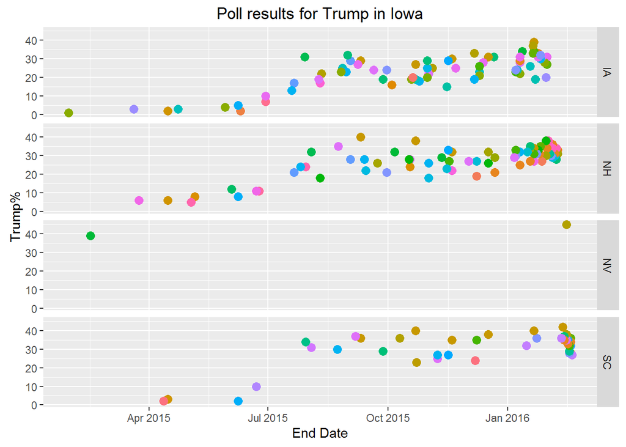

```r
##Your code here

dataQ2a %>% filter(state %in% c('IA','NH','NV','SC') & !is.na(Trump))%>% ggplot(aes(x=end_date,y=Trump,colour=factor(pollster)))+geom_point(size=3)+labs(title="Poll results for Trump in Iowa",x="End Date", y="Trump%")+facet_grid(state~.)+theme(legend.position = "none")
```

So the problem might be, the assumptions I described in Q2C which are independence and homogeneous expectation are not held in reality. From the graphs we can easily see that, the expectation of voting for Trump varies over time (either seasonally or geographic wise), in other words, the population which each pollster house surveyed is not homogeneous in terms of their political opinions over time and across regions. The other independence assumption may also not true because people are tend to be influenced by the economic & social environment.

## Problem 2E

Consider the Trump - Rubio difference. For each poll in IA, NH, SC and NV, compute the error between the prediction and actual election results. Use exploratory data analysis to get an idea of how time and pollster impacts accuracy.

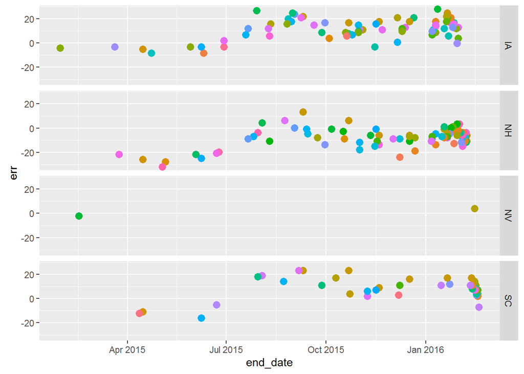

```r
##Your code here

#compute the error of the Trump - Rubio difference between the prediction and actual election results.
dataQ2e <- dataQ2a %>% filter(state %in% c('IA','NH','SC','NV')) %>% mutate(err=diff-actual_diff)

# EDA: plot error over time, color by pollsters
filter(dataQ2e, !is.na(err))%>% ggplot(aes(x=end_date,y=err,colour=pollster))+geom_point(size=3)+facet_grid(state~.)+theme(legend.position = "none") # facet into rows based on state
```

The errors between prediction and actual election resutls seem to fluctuate over time. But it has a convergence tendency, that is, the closer to the election date the smaller errors would be.